# EDA and Univariate

Ishan

2025-04-02

## Objective

This study explores the interplay between physical traits and environmental factors in penguins to uncover significant predictors of body mass and interspecies ecological variations. By focusing on measurable characteristics such as flipper length, culmen dimensions, and stable isotope ratios (δ15N, δ13C), the analysis aims to identify key variables influencing body mass. Insights from this study contribute to understanding how ecological factors and specific traits interact to shape body mass patterns across different penguin populations.

## Feature selection

- Scatterplot Matrix - Identifying relationship

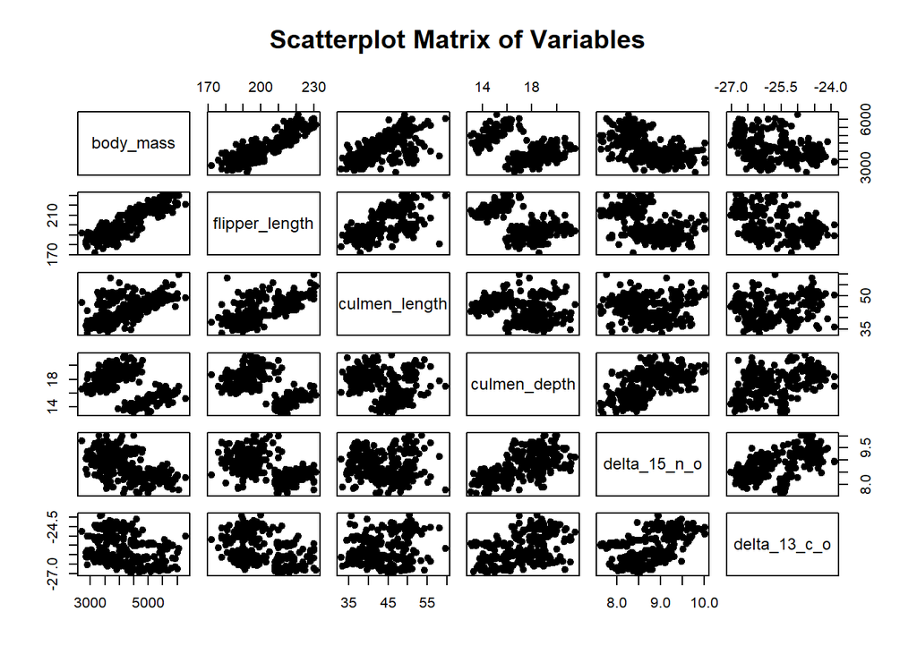

```r
sel_col <- train_df[,c("body_mass","flipper_length","culmen_length","culmen_depth","delta_15_n_o","delta_13_c_o")]
pairs(sel_col, main = "Scatterplot Matrix of Variables", pch = 19, col = "black")
```

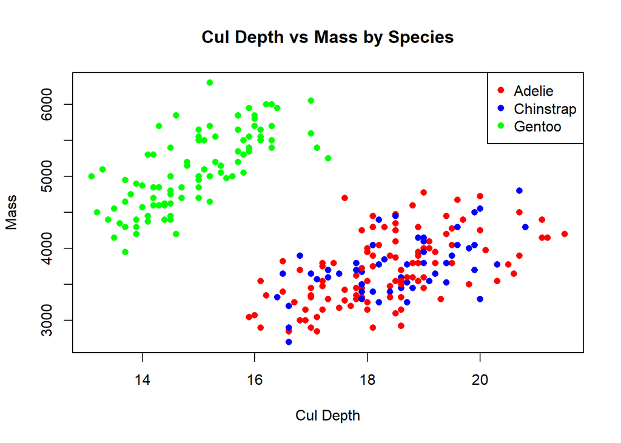

```r
plot(train_df$culmen_depth, train_df$body_mass,
     col = ifelse(train_df$species == "Adelie Penguin (Pygoscelis adeliae)", "red",
                  ifelse(train_df$species == "Chinstrap penguin (Pygoscelis antarctica)", "blue", "green")),
     pch = 16,
     xlab = "Cul Depth",
     ylab = "Mass",
     main = "Cul Depth vs Mass by Species")

# Add legend
legend("topright", legend = c("Adelie", "Chinstrap", "Gentoo"),
       col = c("red", "blue", "green"),pch=16)
```

- Correlation matrix - Identifying relationship

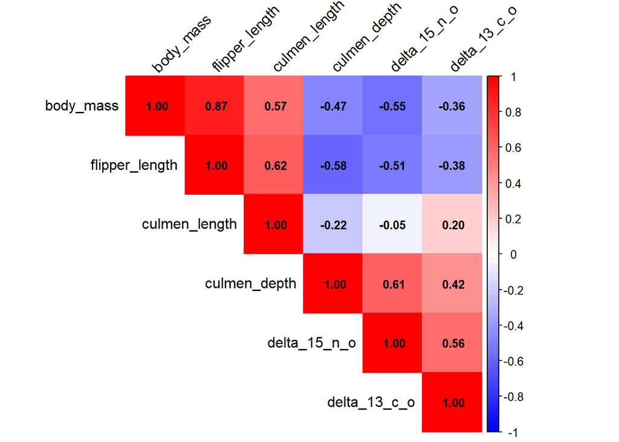

```r
library(corrplot)
# Select only numeric columns
numeric_data <- train_df[, c("body_mass","flipper_length","culmen_length","culmen_depth","delta_15_n_o","delta_13_c_o")]

# Compute correlation matrix
cor_matrix <- cor(numeric_data)

# Plot with values inside
corrplot(cor_matrix, method = "color", type = "upper",
         addCoef.col = "black", # add correlation coefficients
         tl.col = "black", tl.srt = 45, # label color and rotation
         col = colorRampPalette(c("blue", "white", "red"))(100),
         number.cex = 0.8)
```

## Base model

```r
base_model <- lm(body_mass ~ flipper_length + culmen_depth + delta_15_n_o , data = train_df)
summary(base_model)
```

```
##
## Call:
## lm(formula = body_mass ~ flipper_length + culmen_depth + delta_15_n_o,
##     data = train_df)
##
## Residuals:
##     Min      1Q  Median      3Q     Max
## -888.99 -223.47  -45.26  237.35 1076.78
##
## Coefficients:
##                 Estimate Std. Error t value Pr(>|t|)
## (Intercept)    -4518.542    770.135  -5.867 1.37e-08 ***
## flipper_length    50.744      2.192  23.150  < 2e-16 ***
## culmen_depth      59.692     16.130   3.701 0.000263 ***
## delta_15_n_o    -284.876     55.790  -5.106 6.44e-07 ***
## ---
## Signif. codes:  0 '***' 0.001 '**' 0.01 '*' 0.05 '.' 0.1 ' ' 1
##
## Residual standard error: 381.9 on 255 degrees of freedom
## Multiple R-squared:  0.783,  Adjusted R-squared:  0.7805
## F-statistic: 306.8 on 3 and 255 DF,  p-value: < 2.2e-16
```

```r
AIC(base_model)
```

```
## [1] 3820.609
```

- Anova check for categorical variables

```r
# Extract categorical variables (excluding body_mass itself)
cat_vars <- names(train_df)[sapply(train_df, is.character) & !names(train_df) %in% c("body_mass", "studyname", "individual_id", "clutch_completion", "date_egg")]

# Loop through each categorical variable and perform ANOVA
for (X in cat_vars) {
  cat("\n\n### Relationship between body_mass and", X, "###\n")
  #print(table(train_df[[X]]))  # Print category counts

  # Perform ANOVA
  model <- aov(body_mass ~ train_df[[X]], data = train_df)
  #summary(model)  # Print ANOVA results
  print(summary(model))
}
```

```
##
##
## ### Relationship between body_mass and species ###
##                Df    Sum Sq  Mean Sq F value Pr(>F)
## train_df[[X]]   2 111389256 55694628   237.4 <2e-16 ***
## Residuals     256  60062598   234620
## ---
## Signif. codes:  0 '***' 0.001 '**' 0.01 '*' 0.05 '.' 0.1 ' ' 1
##
##
## ### Relationship between body_mass and island ###
##                Df    Sum Sq  Mean Sq F value Pr(>F)
## train_df[[X]]   2  65177118 32588559    78.5 <2e-16 ***
## Residuals     256 106274735   415136
## ---
## Signif. codes:  0 '***' 0.001 '**' 0.01 '*' 0.05 '.' 0.1 ' ' 1
##
##
## ### Relationship between body_mass and sex ###
##                Df    Sum Sq  Mean Sq F value   Pr(>F)
## train_df[[X]]   1  33058630 33058630   61.39 1.24e-13 ***
## Residuals     257 138393223   538495
## ---
## Signif. codes:  0 '***' 0.001 '**' 0.01 '*' 0.05 '.' 0.1 ' ' 1
```

```r
cat_vars <- c("species", "island", "sex")

# Perform Chi-square tests between all pairs
for (i in 1:(length(cat_vars)-1)) {
  for (j in (i+1):length(cat_vars)) {
    cat("\nChi-Square Test for", cat_vars[i], "and", cat_vars[j], "\n")
    print(chisq.test(table(train_df[[cat_vars[i]]], train_df[[cat_vars[j]]])))
  }
}
```

```
##
## Chi-Square Test for species and island
##
##  Pearson's Chi-squared test
##
## data:  table(train_df[[cat_vars[i]]], train_df[[cat_vars[j]]])
## X-squared = 227.17, df = 4, p-value < 2.2e-16
##
##
## Chi-Square Test for species and sex
##
##  Pearson's Chi-squared test
##
## data:  table(train_df[[cat_vars[i]]], train_df[[cat_vars[j]]])
## X-squared = 0.0036547, df = 2, p-value = 0.9982
##
##
## Chi-Square Test for island and sex
##
##  Pearson's Chi-squared test
##
## data:  table(train_df[[cat_vars[i]]], train_df[[cat_vars[j]]])
## X-squared = 0.16251, df = 2, p-value = 0.922
```

p-value(2.2e-16)<0.05, two variables are correlated: species and island

### Modelling

- Full model

```r
f_model <- lm(body_mass ~ . - studyname - sample_number - individual_id - individual_id - date_egg, data = train_df)
summary(f_model)
```

```
##
## Call:
## lm(formula = body_mass ~ . - studyname - sample_number - individual_id -
##     individual_id - date_egg, data = train_df)
##
## Residuals:
##     Min      1Q  Median      3Q     Max
## -634.66 -198.31   -5.52  176.68  776.27
##
## Coefficients:
##                                                  Estimate Std. Error t value
## (Intercept)                                      1682.886   1190.910   1.413
## speciesChinstrap penguin (Pygoscelis antarctica) -247.467    107.342  -2.305
## speciesGentoo penguin (Pygoscelis papua)          814.174    158.225   5.146
## islandDream                                         0.408     68.231   0.006
## islandTorgersen                                   -28.338     70.463  -0.402
## clutch_completionYes                               70.638     57.520   1.228
## culmen_length                                      18.898      7.834   2.412
## culmen_depth                                       54.916     22.259   2.467
## flipper_length                                     18.282      3.416   5.352
## sexMALE                                           459.270     54.776   8.384
## delta_15_n_o                                     -191.349     51.317  -3.729
## delta_13_c_o                                       68.993     35.186   1.961
##                                                  Pr(>|t|)
## (Intercept)                                      0.158882
## speciesChinstrap penguin (Pygoscelis antarctica) 0.021973 *
## speciesGentoo penguin (Pygoscelis papua)         5.44e-07 ***
## islandDream                                      0.995234
## islandTorgersen                                  0.687908
## clutch_completionYes                             0.220594
## culmen_length                                    0.016578 *
## culmen_depth                                     0.014297 *
## flipper_length                                   1.99e-07 ***
## sexMALE                                          3.92e-15 ***
## delta_15_n_o                                     0.000239 ***
## delta_13_c_o                                     0.051026 .
## ---
## Signif. codes:  0 '***' 0.001 '**' 0.01 '*' 0.05 '.' 0.1 ' ' 1
##
## Residual standard error: 287.2 on 247 degrees of freedom
## Multiple R-squared:  0.8812, Adjusted R-squared:  0.8759
## F-statistic: 166.5 on 11 and 247 DF,  p-value: < 2.2e-16
```

```r
AIC(f_model)
```

```
## [1] 3680.714
```

- stepwise selection - both ways

```r
step_model <- step(f_model, direction = "both")
```

```
## Start:  AIC=2943.7
## body_mass ~ (studyname + sample_number + species + island + individual_id +
##     clutch_completion + date_egg + culmen_length + culmen_depth +
##     flipper_length + sex + delta_15_n_o + delta_13_c_o) - studyname -
##     sample_number - individual_id - individual_id - date_egg
##
##                     Df Sum of Sq      RSS    AIC
## - island             2     19299 20394203 2939.9
## - clutch_completion  1    124405 20499309 2943.3
## <none>                           20374904 2943.7
## - delta_13_c_o       1    317152 20692056 2945.7
## - culmen_length      1    480054 20854959 2947.7
## - culmen_depth       1    502121 20877025 2948.0
## - delta_15_n_o       1   1146915 21521819 2955.9
## - flipper_length     1   2362563 22737467 2970.1
## - species            2   3802045 24176950 2984.0
## - sex                1   5798906 26173811 3006.6
##
## Step:  AIC=2939.95
## body_mass ~ species + clutch_completion + culmen_length + culmen_depth +
##     flipper_length + sex + delta_15_n_o + delta_13_c_o
##
##                     Df Sum of Sq      RSS    AIC
## - clutch_completion  1    137568 20531771 2939.7
## <none>                           20394203 2939.9
## - delta_13_c_o       1    313170 20707373 2941.9
## + island             2     19299 20374904 2943.7
## - culmen_length      1    472551 20866754 2943.9
## - culmen_depth       1    508403 20902606 2944.3
## - delta_15_n_o       1   1137194 21531397 2952.0
## - flipper_length     1   2365400 22759603 2966.4
## - species            2   4633412 25027615 2989.0
## - sex                1   5851677 26245880 3003.3
##
## Step:  AIC=2939.69
## body_mass ~ species + culmen_length + culmen_depth + flipper_length +
##     sex + delta_15_n_o + delta_13_c_o
##
##                     Df Sum of Sq      RSS    AIC
## <none>                           20531771 2939.7
## + clutch_completion  1    137568 20394203 2939.9
## - delta_13_c_o       1    313607 20845378 2941.6
## + island             2     32462 20499309 2943.3
## - culmen_length      1    470356 21002127 2943.6
## - culmen_depth       1    494373 21026144 2943.8
## - delta_15_n_o       1   1244568 21776339 2952.9
## - flipper_length     1   2496541 23028312 2967.4
## - species            2   4595784 25127555 2988.0
## - sex                1   5846413 26378184 3002.6
```

```r
summary(step_model)
```

```
##
## Call:
## lm(formula = body_mass ~ species + culmen_length + culmen_depth +
##     flipper_length + sex + delta_15_n_o + delta_13_c_o, data = train_df)
##
## Residuals:
##     Min      1Q  Median      3Q     Max
## -682.74 -195.77   -2.17  183.99  781.56
##
## Coefficients:
##                                                  Estimate Std. Error t value
## (Intercept)                                      1737.696   1182.680   1.469
## speciesChinstrap penguin (Pygoscelis antarctica) -243.743    100.202  -2.433
## speciesGentoo penguin (Pygoscelis papua)          817.589    147.317   5.550
## culmen_length                                      18.672      7.802   2.393
## culmen_depth                                       54.439     22.188   2.453
## flipper_length                                     18.463      3.349   5.513
## sexMALE                                           460.337     54.560   8.437
## delta_15_n_o                                     -196.929     50.587  -3.893
## delta_13_c_o                                       67.765     34.678   1.954
##                                                  Pr(>|t|)
## (Intercept)                                      0.143012
## speciesChinstrap penguin (Pygoscelis antarctica) 0.015697 *
## speciesGentoo penguin (Pygoscelis papua)         7.28e-08 ***
## culmen_length                                    0.017443 *
## culmen_depth                                     0.014831 *
## flipper_length                                   8.76e-08 ***
## sexMALE                                          2.64e-15 ***
## delta_15_n_o                                     0.000127 ***
## delta_13_c_o                                     0.051803 .
## ---
## Signif. codes:  0 '***' 0.001 '**' 0.01 '*' 0.05 '.' 0.1 ' ' 1
##
## Residual standard error: 286.6 on 250 degrees of freedom
## Multiple R-squared:  0.8802, Adjusted R-squared:  0.8764
## F-statistic: 229.7 on 8 and 250 DF,  p-value: < 2.2e-16
```

```r
AIC(step_model)
```

```
## [1] 3676.7
```

- check multicollinearity

```r
library(car)
vif(step_model)
```

```
##                     GVIF Df GVIF^(1/(2*Df))
## species        58.954675  2        2.770956
## culmen_length   5.727447  1        2.393209
## culmen_depth    6.330763  1        2.516101
## flipper_length  6.683902  1        2.585324
## sex             2.346626  1        1.531870
## delta_15_n_o    2.474410  1        1.573026
## delta_13_c_o    2.393459  1        1.547081
```

- Check interaction terms

```r
t_int_model <- lm(body_mass ~ flipper_length * culmen_depth , data = train_df)
t_no_int_model <- lm(body_mass ~ flipper_length + culmen_depth , data = train_df)

#Ho: Model without interaction is better
#Ha: Model with interaction is better

anova(t_no_int_model, t_int_model)
```

```
## Analysis of Variance Table
##
## Model 1: body_mass ~ flipper_length + culmen_depth
## Model 2: body_mass ~ flipper_length * culmen_depth
##   Res.Df      RSS Df Sum of Sq      F    Pr(>F)
## 1    256 40999809
## 2    255 37444345  1   3555463 24.213 1.549e-06 ***
## ---
## Signif. codes:  0 '***' 0.001 '**' 0.01 '*' 0.05 '.' 0.1 ' ' 1
```

Since p-value<0.05, this suggests that the interaction term significantly improves the model, so t_int_model is better.

```r
t_int_model2 <- lm(body_mass ~ flipper_length * delta_15_n_o , data = train_df)
t_no_int_model2 <- lm(body_mass ~ flipper_length + delta_15_n_o , data = train_df)

#Ho: Model without interaction is better
#Ha: Model with interaction is better

anova(t_no_int_model2, t_int_model2)
```

```
## Analysis of Variance Table
##
## Model 1: body_mass ~ flipper_length + delta_15_n_o
## Model 2: body_mass ~ flipper_length * delta_15_n_o
##   Res.Df      RSS Df Sum of Sq      F   Pr(>F)
## 1    256 39194237
## 2    255 38092386  1   1101851 7.3761 0.007062 **
## ---
## Signif. codes:  0 '***' 0.001 '**' 0.01 '*' 0.05 '.' 0.1 ' ' 1
```

- Final model

```r
model <- lm(body_mass ~ flipper_length * culmen_depth +flipper_length * delta_15_n_o + sex, data = train_df)
summary(model)
```

```
##
## Call:
## lm(formula = body_mass ~ flipper_length * culmen_depth + flipper_length *
##     delta_15_n_o + sex, data = train_df)
##
## Residuals:
##     Min      1Q  Median      3Q     Max
## -658.19 -215.84    3.21  202.57  781.71
##
## Coefficients:
##                               Estimate Std. Error t value Pr(>|t|)
## (Intercept)                 -35804.203   7638.676  -4.687 4.54e-06 ***
## flipper_length                 211.893     37.304   5.680 3.70e-08 ***
## culmen_depth                   772.686    283.523   2.725 0.006875 **
## delta_15_n_o                  2215.682    737.886   3.003 0.002945 **
## sexMALE                        530.152     53.148   9.975  < 2e-16 ***
## flipper_length:culmen_depth     -3.931      1.398  -2.811 0.005328 **
## flipper_length:delta_15_n_o    -12.529      3.733  -3.356 0.000912 ***
## ---
## Signif. codes:  0 '***' 0.001 '**' 0.01 '*' 0.05 '.' 0.1 ' ' 1
##
## Residual standard error: 306.4 on 252 degrees of freedom
## Multiple R-squared:  0.862,  Adjusted R-squared:  0.8587
## F-statistic: 262.4 on 6 and 252 DF,  p-value: < 2.2e-16
```

```r
AIC(model)
```

```
## [1] 3709.375
```

- Step on Final model

```r
new_model <- step(model, direction = "both")
```

```
## Start:  AIC=2972.36
## body_mass ~ flipper_length * culmen_depth + flipper_length *
##     delta_15_n_o + sex
##
##                               Df Sum of Sq      RSS    AIC
## <none>                                     23654999 2972.4
## - flipper_length:culmen_depth  1    741706 24396705 2978.4
## - flipper_length:delta_15_n_o  1   1057419 24712418 2981.7
## - sex                          1   9340146 32995145 3056.6
```

```r
summary(new_model)
```

```
##
## Call:
## lm(formula = body_mass ~ flipper_length * culmen_depth + flipper_length *
##     delta_15_n_o + sex, data = train_df)
##
## Residuals:
##     Min      1Q  Median      3Q     Max
## -658.19 -215.84    3.21  202.57  781.71
##
## Coefficients:
##                               Estimate Std. Error t value Pr(>|t|)
## (Intercept)                 -35804.203   7638.676  -4.687 4.54e-06 ***
## flipper_length                 211.893     37.304   5.680 3.70e-08 ***
## culmen_depth                   772.686    283.523   2.725 0.006875 **
## delta_15_n_o                  2215.682    737.886   3.003 0.002945 **
## sexMALE                        530.152     53.148   9.975  < 2e-16 ***
## flipper_length:culmen_depth     -3.931      1.398  -2.811 0.005328 **
## flipper_length:delta_15_n_o    -12.529      3.733  -3.356 0.000912 ***
## ---
## Signif. codes:  0 '***' 0.001 '**' 0.01 '*' 0.05 '.' 0.1 ' ' 1
##
## Residual standard error: 306.4 on 252 degrees of freedom
## Multiple R-squared:  0.862,  Adjusted R-squared:  0.8587
## F-statistic: 262.4 on 6 and 252 DF,  p-value: < 2.2e-16
```

```r
AIC(new_model)
```

```
## [1] 3709.375
```

## Interpretation of the model

predicted body mass = beta0 + beta1 * flipper_length + beta2 * culmen_depth + beta3 * delta_15N + beta4 * sexMale + beta5 * flipper_length * culmen_depth + beta6 * flipper_length * delta_15N predicted body mass = (-35804.203) + (211.893) * flipper_length + (772.686) * culmen_depth + (2215.682) * delta_15N + (530.152) * sexMale + (-3.931) * flipper_length * culmen_depth + (-12.529) * flipper_length*delta_15N

- Intercept (-35804.203): The body mass when all continuous predictors are zero and sex is the reference level (FEMALE). This large negative value isn’t directly interpretable since the body mass never reach zero in practice.
- flipper_length (211.893): For each 1 mm increase in flipper length, body mass increases by approximately 212 grams, holding other variables constant.
- culmen_depth (772.686): For each 1 mm increase in culmen depth, body mass increases by about 773 grams when other variables are held constant.
- delta_15_n_o (2215.682): For each unit increase in delta_15_n_o, body mass increases by about 2216 grams, holding other variables constant.
- sexMALE (530.152): Male penguins are about 530 grams heavier than females on average, controlling for other variables.
- Interaction terms:

– flipper_length:culmen_depth (-3.931): The effect of flipper length on body mass decreases by about 3.9 grams for each 1 mm increase in culmen depth.

– flipper_length:delta_15_n_o (-12.529): The effect of flipper length on body mass decreases by about 12.5 grams for each unit increase in delta_15_n_o.

- Linearity - Residuals vs Fitted plot
- Independence - Residuals plot
- Normality - Normal Q-Q plot
- Homoscedasticity - Residuals vs Fitted plot
- No multicollinearity - vif

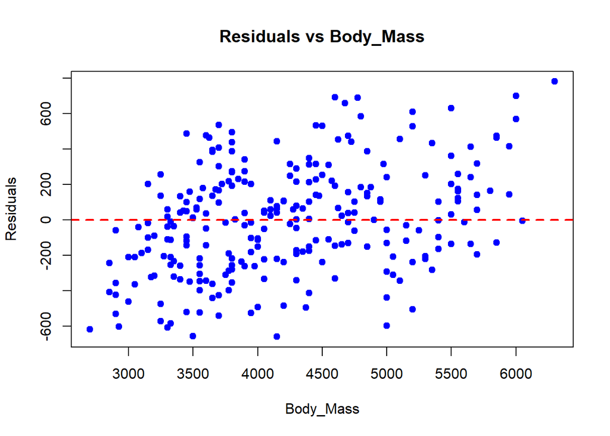

```r
par(mfrow = c(1, 1))  # Ensure single plot window
plot(train_df$body_mass, residuals(model),
     main = "Residuals vs Body_Mass",
     xlab = "Body_Mass", ylab = "Residuals",
     pch = 19, col = "blue")

# Reference line at y = 0
abline(h = 0, col = "red", lwd = 2, lty = 2)
```

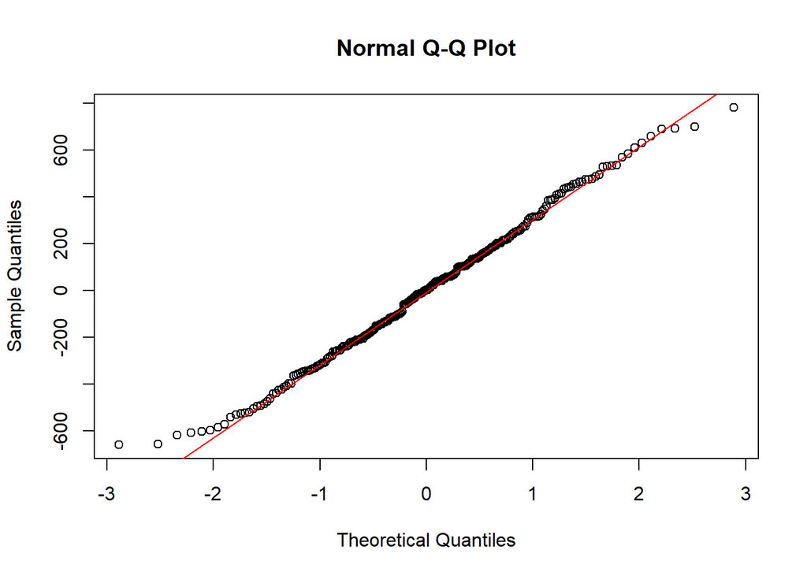

```r
#Normalitty of residuals
qqnorm(residuals(model))
qqline(residuals(model), col="red")
```

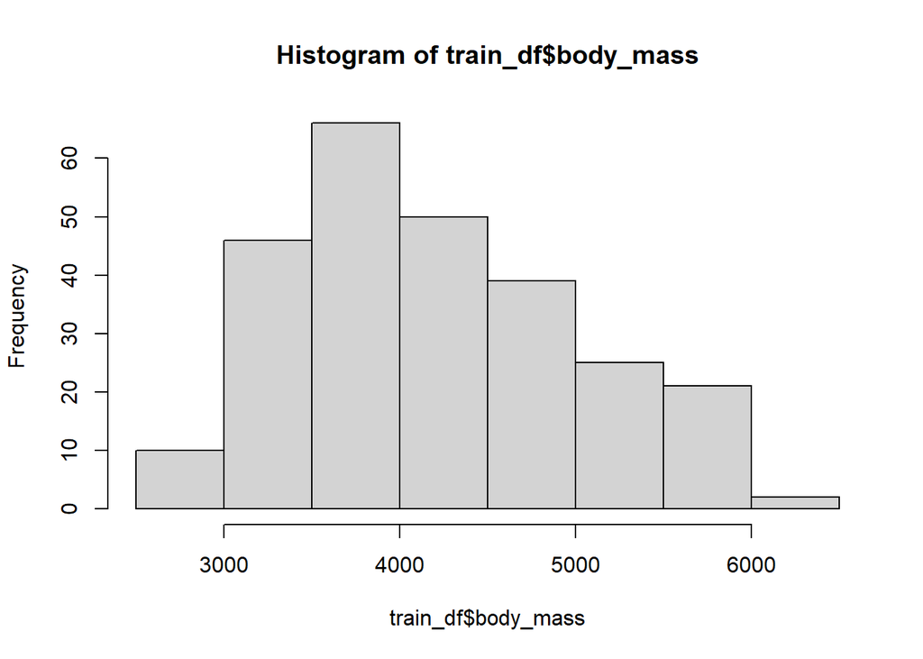

```r
hist(train_df$body_mass)
```

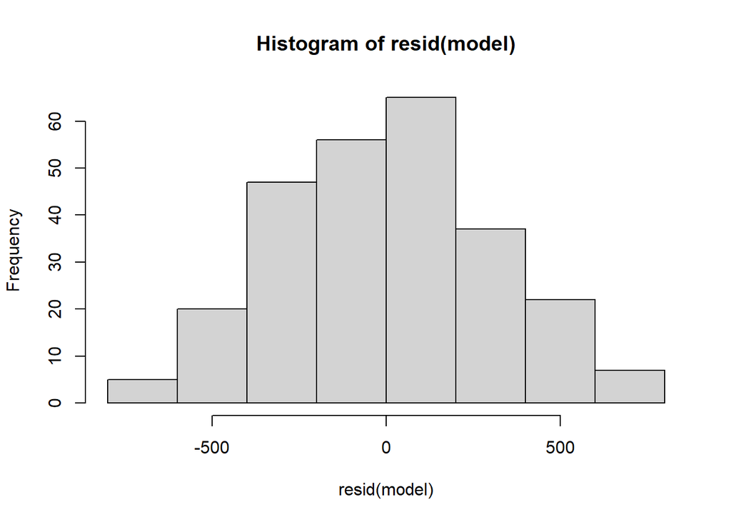

```r
hist(resid(model))
```

- Box-cox transformation

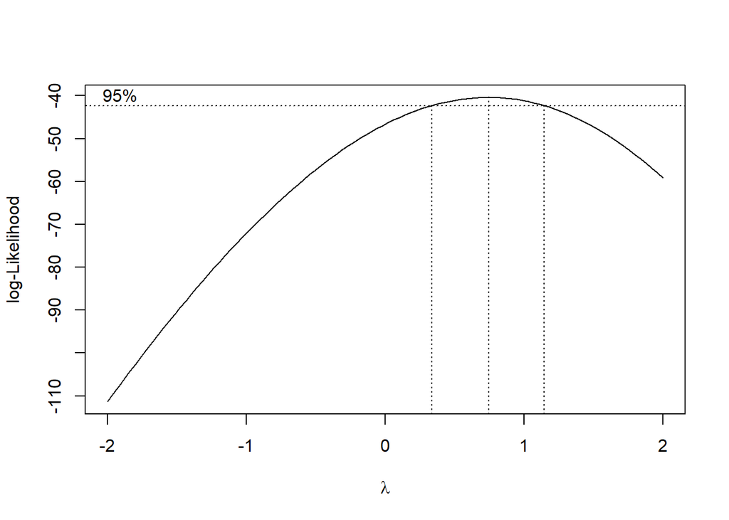

```r
library(MASS)
boxcox_result <- boxcox(model, lambda = seq(-2, 2, by = 0.1))
```

```r
optimal_lambda <- boxcox_result$x[which.max(boxcox_result$y)]
cat("Optimal Lambda:", optimal_lambda, "\n")
```

```
## Optimal Lambda: 0.7474747
```

```r
model_bc <- lm(body_mass^0.75 ~ flipper_length * culmen_depth +flipper_length * delta_15_n_o + sex, data = train_df)
summary(model_bc)
```

```
##
## Call:
## lm(formula = body_mass^0.75 ~ flipper_length * culmen_depth +
##     flipper_length * delta_15_n_o + sex, data = train_df)
##
## Residuals:
##     Min      1Q  Median      3Q     Max
## -62.597 -20.050   0.852  19.419  65.760
##
## Coefficients:
##                               Estimate Std. Error t value Pr(>|t|)
## (Intercept)                 -3090.1398   711.6723  -4.342 2.05e-05 ***
## flipper_length                 19.1381     3.4755   5.506 9.01e-08 ***
## culmen_depth                   76.6466    26.4150   2.902  0.00404 **
## delta_15_n_o                  184.5084    68.7466   2.684  0.00776 **
## sexMALE                        49.1010     4.9516   9.916  < 2e-16 ***
## flipper_length:culmen_depth    -0.3889     0.1303  -2.985  0.00311 **
## flipper_length:delta_15_n_o    -1.0566     0.3478  -3.038  0.00263 **
## ---
## Signif. codes:  0 '***' 0.001 '**' 0.01 '*' 0.05 '.' 0.1 ' ' 1
##
## Residual standard error: 28.54 on 252 degrees of freedom
## Multiple R-squared:   0.86,  Adjusted R-squared:  0.8566
## F-statistic: 257.9 on 6 and 252 DF,  p-value: < 2.2e-16
```

```r
AIC(model_bc)
```

```
## [1] 2479.973
```

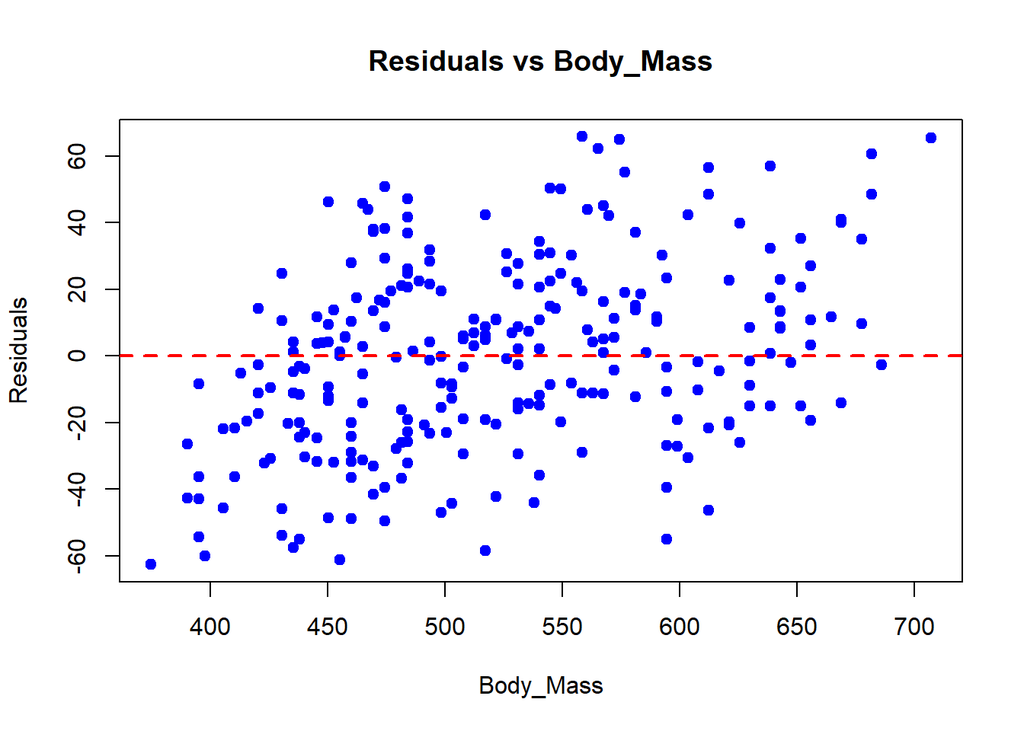

```r
par(mfrow = c(1, 1))  # Ensure single plot window
plot(train_df$body_mass^(0.75), residuals(model_bc),
     main = "Residuals vs Body_Mass",
     xlab = "Body_Mass", ylab = "Residuals",
     pch = 19, col = "blue")

# Reference line at y = 0
abline(h = 0, col = "red", lwd = 2, lty = 2)
```

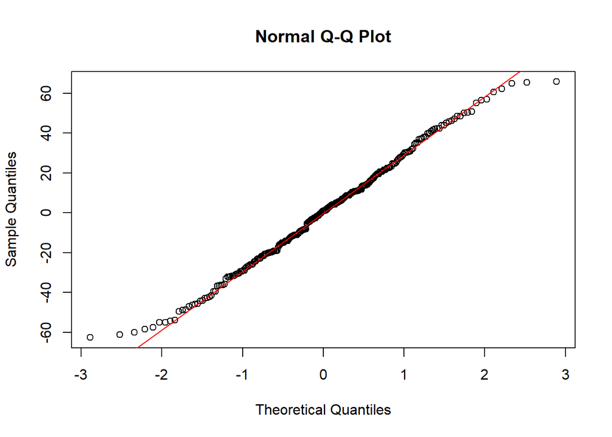

```r
#Normalitty of residuals
qqnorm(residuals(model_bc))
qqline(residuals(model_bc), col="red")
```

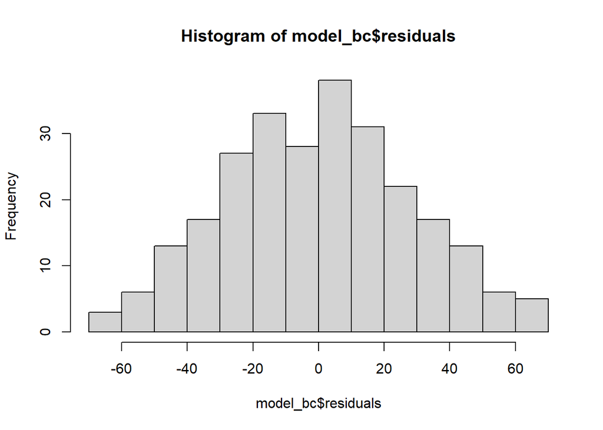

```r
hist(model_bc$residuals)
```

```r
vif(model, type = "predictor")
```

```
##                      GVIF Df GVIF^(1/(2*Df))             Interacts With
## flipper_length    1.94818  5        1.068964 culmen_depth, delta_15_n_o
## culmen_depth   1160.16025  3        3.241552             flipper_length
## delta_15_n_o    438.47848  3        2.756289             flipper_length
## sex               1.94818  1        1.395772                       --
##                                          Other Predictors
## flipper_length                                        sex
## culmen_depth                            delta_15_n_o, sex
## delta_15_n_o                            culmen_depth, sex
## sex            flipper_length, culmen_depth, delta_15_n_o
```

## check with test dataset

```r
test <- read.csv("test_penguins.csv")
colnames(test)<- c("studyname","sample_number","species","island","individual_id","clutch_completion","date_egg","culmen_length","culmen_depth","flipper_length","body_mass","sex","delta_15_n_o","delta_13_c_o")

test$pred_mass <- (predict(model_bc, newdata = test))^(1/0.75)
# test$pred_mass <- test$pred_mass
```

```r
test$residuals <- test$body_mass - test$pred_mass

rmse <- sqrt(mean(test$residuals)^2)

mae <- mean(abs(test$residuals))

sst <- sum((test$body_mass - mean(test$body_mass))^2)
sse <- sum((test$residuals)^2)
r_squared <- 1 - (sse / sst)

cat("\n### Testing Data ###\n")
```

```
##
## ### Testing Data ###
```

```r
cat("Test RMSE:", rmse, "\n")
```

```
## Test RMSE: 53.92443
```

```r
cat("Test MAE:", mae, "\n")
```

```
## Test MAE: 222.096
```

```r
cat("Test R²:", r_squared,"\n")
```

```
## Test R²: 0.8739489
```